# 23050196 Riwaj Neupane

1. Data Preparation

Import the dataset

```python
import pandas as pd


df = pd.read_csv("Customer Service_Requests_from_2010_to_Present.csv", low_memory=False)
df
```

|  | Unique Key | Created Date | Closed Date | Agency | Agency Name | Complaint Type | Descriptor | Location Type | Incident Zip | Incident Address | ... | Bridge Highway Name | Bridge Highway Direction | Road Ramp | Bridge Highway Segment | Garage Lot Name | Ferry Direction | Ferry Terminal Name | Latitude | Longitude | Location |
| --- | --- | --- | --- | --- | --- | --- | --- | --- | --- | --- | --- | --- | --- | --- | --- | --- | --- | --- | --- | --- | --- |
| 0 | 32310363 | 12/31/2015 11:59:45 PM | 01-01-16 0:55 | NYPD | New York City Police Department | Noise - Street/Sidewalk | Loud Music/Party | Street/Sidewalk | 10034.0 | 71 VERMILYEA AVENUE | ... | NaN | NaN | NaN | NaN | NaN | NaN | NaN | 40.865682 | -73.923501 | (40.86568153633767, -73.92350095571744) |
| 1 | 32309934 | 12/31/2015 11:59:44 PM | 01-01-16 1:26 | NYPD | New York City Police Department | Blocked Driveway | No Access | Street/Sidewalk | 11105.0 | 27-07 23 AVENUE | ... | NaN | NaN | NaN | NaN | NaN | NaN | NaN | 40.775945 | -73.915094 | (40.775945312321085, -73.91509393898605) |
| 2 | 32309159 | 12/31/2015 11:59:29 PM | 01-01-16 4:51 | NYPD | New York City Police Department | Blocked Driveway | No Access | Street/Sidewalk | 10458.0 | 2897 VALENTINE AVENUE | ... | NaN | NaN | NaN | NaN | NaN | NaN | NaN | 40.870325 | -73.888525 | (40.870324522111424, -73.88852464418646) |
| 3 | 32305098 | 12/31/2015 11:57:46 PM | 01-01-16 7:43 | NYPD | New York City Police Department | Illegal Parking | Commercial Overnight Parking | Street/Sidewalk | 10461.0 | 2940 BAISLEY AVENUE | ... | NaN | NaN | NaN | NaN | NaN | NaN | NaN | 40.835994 | -73.828379 | (40.83599404683083, -73.82837939584206) |
| 4 | 32306529 | 12/31/2015 11:56:58 PM | 01-01-16 3:24 | NYPD | New York City Police Department | Illegal Parking | Blocked Sidewalk | Street/Sidewalk | 11373.0 | 87-14 57 ROAD | ... | NaN | NaN | NaN | NaN | NaN | NaN | NaN | 40.733060 | -73.874170 | (40.733059618956815, -73.87416975810375) |
| ... | ... | ... | ... | ... | ... | ... | ... | ... | ... | ... | ... | ... | ... | ... | ... | ... | ... | ... | ... | ... | ... |
| 300693 | 30281872 | 03/29/2015 12:33:41 AM | NaN | NYPD | New York City Police Department | Noise - Commercial | Loud Music/Party | Club/Bar/Restaurant | NaN | CRESCENT AVENUE | ... | NaN | NaN | NaN | NaN | NaN | NaN | NaN | NaN | NaN | NaN |
| 300694 | 30281230 | 03/29/2015 12:33:28 AM | 03/29/2015 02:33:59 AM | NYPD | New York City Police Department | Blocked Driveway | Partial Access | Street/Sidewalk | 11418.0 | 100-17 87 AVENUE | ... | NaN | NaN | NaN | NaN | NaN | NaN | NaN | 40.694077 | -73.846087 | (40.69407728322387, -73.8460866160573) |
| 300695 | 30283424 | 03/29/2015 12:33:03 AM | 03/29/2015 03:40:20 AM | NYPD | New York City Police Department | Noise - Commercial | Loud Music/Party | Club/Bar/Restaurant | 11206.0 | 162 THROOP AVENUE | ... | NaN | NaN | NaN | NaN | NaN | NaN | NaN | 40.699590 | -73.944234 | (40.69959035300927, -73.94423377144169) |
| 300696 | 30280004 | 03/29/2015 12:33:02 AM | 03/29/2015 04:38:35 AM | NYPD | New York City Police Department | Noise - Commercial | Loud Music/Party | Club/Bar/Restaurant | 10461.0 | 3151 EAST TREMONT AVENUE | ... | NaN | NaN | NaN | NaN | NaN | NaN | NaN | 40.837708 | -73.834587 | (40.8377075854206, -73.83458731019586) |
| 300697 | 30281825 | 03/29/2015 12:33:01 AM | 03/29/2015 04:41:50 AM | NYPD | New York City Police Department | Noise - Commercial | Loud Music/Party | Store/Commercial | 10036.0 | 251 WEST 48 STREET | ... | NaN | NaN | NaN | NaN | NaN | NaN | NaN | 40.760583 | -73.985922 | (40.76058322950115, -73.98592204392392) |

300698 rows × 53 columns

```python
df.info()
```

```
<class 'pandas.core.frame.DataFrame'>
RangeIndex: 300698 entries, 0 to 300697
Data columns (total 53 columns):
 #   Column                          Non-Null Count   Dtype
---  ------                          --------------   -----
 0   Unique Key                      300698 non-null  int64
 1   Created Date                    300698 non-null  object
 2   Closed Date                     298534 non-null  object
 3   Agency                          300698 non-null  object
 4   Agency Name                     300698 non-null  object
 5   Complaint Type                  300698 non-null  object
 6   Descriptor                      294784 non-null  object
 7   Location Type                   300567 non-null  object
 8   Incident Zip                    298083 non-null  float64
 9   Incident Address                256288 non-null  object
```

[output cut: 45 more lines]

```python
df.describe(include ="all")
```

|  | Unique Key | Created Date | Closed Date | Agency | Agency Name | Complaint Type | Descriptor | Location Type | Incident Zip | Incident Address | ... | Bridge Highway Name | Bridge Highway Direction | Road Ramp | Bridge Highway Segment | Garage Lot Name | Ferry Direction | Ferry Terminal Name | Latitude | Longitude | Location |
| --- | --- | --- | --- | --- | --- | --- | --- | --- | --- | --- | --- | --- | --- | --- | --- | --- | --- | --- | --- | --- | --- |
| count | 3.006980e+05 | 300698 | 298534 | 300698 | 300698 | 300698 | 294784 | 300567 | 298083.000000 | 256288 | ... | 243 | 243 | 213 | 213 | 0.0 | 1 | 2 | 297158.000000 | 297158.000000 | 297158 |
| unique | NaN | 259493 | 237165 | 1 | 3 | 24 | 45 | 18 | NaN | 107652 | ... | 29 | 34 | 2 | 160 | NaN | 1 | 2 | NaN | NaN | 126048 |
| top | NaN | 07-11-15 23:04 | 11-08-15 7:34 | NYPD | New York City Police Department | Blocked Driveway | Loud Music/Party | Street/Sidewalk | NaN | 1207 BEACH AVENUE | ... | FDR Dr | East/Queens Bound | Roadway | East 96th St (Exit 14) - Triborough Br (Exit 17) | NaN | Manhattan Bound | St. George Terminal (Staten Island) | NaN | NaN | (40.83036235589997, -73.86602154214397) |
| freq | NaN | 9 | 24 | 300698 | 300690 | 77044 | 61430 | 249299 | NaN | 904 | ... | 33 | 21 | 162 | 6 | NaN | 1 | 1 | NaN | NaN | 902 |
| mean | 3.130054e+07 | NaN | NaN | NaN | NaN | NaN | NaN | NaN | 10848.888645 | NaN | ... | NaN | NaN | NaN | NaN | NaN | NaN | NaN | 40.725885 | -73.925630 | NaN |
| std | 5.738547e+05 | NaN | NaN | NaN | NaN | NaN | NaN | NaN | 583.182081 | NaN | ... | NaN | NaN | NaN | NaN | NaN | NaN | NaN | 0.082012 | 0.078454 | NaN |
| min | 3.027948e+07 | NaN | NaN | NaN | NaN | NaN | NaN | NaN | 83.000000 | NaN | ... | NaN | NaN | NaN | NaN | NaN | NaN | NaN | 40.499135 | -74.254937 | NaN |
| 25% | 3.080118e+07 | NaN | NaN | NaN | NaN | NaN | NaN | NaN | 10310.000000 | NaN | ... | NaN | NaN | NaN | NaN | NaN | NaN | NaN | 40.669796 | -73.972142 | NaN |
| 50% | 3.130436e+07 | NaN | NaN | NaN | NaN | NaN | NaN | NaN | 11208.000000 | NaN | ... | NaN | NaN | NaN | NaN | NaN | NaN | NaN | 40.718661 | -73.931781 | NaN |
| 75% | 3.178446e+07 | NaN | NaN | NaN | NaN | NaN | NaN | NaN | 11238.000000 | NaN | ... | NaN | NaN | NaN | NaN | NaN | NaN | NaN | 40.781840 | -73.876805 | NaN |
| max | 3.231065e+07 | NaN | NaN | NaN | NaN | NaN | NaN | NaN | 11697.000000 | NaN | ... | NaN | NaN | NaN | NaN | NaN | NaN | NaN | 40.912869 | -73.700760 | NaN |

11 rows × 53 columns

Convert the columns "Created Date" and "Closed Date" to datetime datatype and create a new column "Request_Closing_Time" as the time elapsed between request creation and request closing

```python
print("Before:")
print("Data Types:")
print(df.dtypes)
print("\nDataFrame:")
```

```
Before:
Data Types:
Unique Key                          int64
Created Date                       object
Closed Date                        object
Agency                             object
Agency Name                        object
Complaint Type                     object
Descriptor                         object
Location Type                      object
Incident Zip                      float64
Incident Address                   object
Street Name                        object
Cross Street 1                     object
Cross Street 2                     object
Intersection Street 1              object
Intersection Street 2              object
Address Type                       object
City                               object
Landmark                           object
Facility Type                      object
Status                             object
Due Date                           object
Resolution Description             object
Resolution Action Updated Date     object
Community Board                    object
Borough                            object
X Coordinate (State Plane)        float64
Y Coordinate (State Plane)        float64
Park Facility Name                 object
Park Borough                       object
School Name                        object
School Number                      object
School Region                      object
School Code                        object
School Phone Number                object
School Address                     object
School City                        object
School State                       object
School Zip                         object
School Not Found                   object
School or Citywide Complaint      float64
Vehicle Type                      float64
Taxi Company Borough              float64
Taxi Pick Up Location             float64
Bridge Highway Name                object
Bridge Highway Direction           object
Road Ramp                          object
Bridge Highway Segment             object
Garage Lot Name                   float64
Ferry Direction                    object
Ferry Terminal Name                object
Latitude                          float64
Longitude                         float64
Location                           object
dtype: object

DataFrame:
```

```python
df['Created Date'] = pd.to_datetime(df['Created Date'])
df['Closed Date'] = pd.to_datetime(df['Closed Date'])

# Creating new column called Request_Closing_Time
df['Request_Closing_Time'] = df['Closed Date'] - df['Created Date']

# AFTER: Display final state
print("\nAfter:")
print(df.dtypes)
print("\nDataFrame:")
print(df)
df
```

```
After:
Unique Key                                  int64
Created Date                       datetime64[ns]
Closed Date                        datetime64[ns]
Agency                                     object
Agency Name                                object
Complaint Type                             object
Descriptor                                 object
Location Type                              object
Incident Zip                              float64
Incident Address                           object
Street Name                                object
Cross Street 1                             object
Cross Street 2                             object
Intersection Street 1                      object
Intersection Street 2                      object
Address Type                               object
City                                       object
Landmark                                   object
Facility Type                              object
Status                                     object
Due Date                                   object
Resolution Description                     object
Resolution Action Updated Date             object
Community Board                            object
Borough                                    object
X Coordinate (State Plane)                float64
Y Coordinate (State Plane)                float64
Park Facility Name                         object
Park Borough                               object
School Name                                object
School Number                              object
School Region                              object
School Code                                object
School Phone Number                        object
School Address                             object
School City                                object
School State                               object
School Zip                                 object
School Not Found                           object
```

[output cut: 95 more lines]

```

                                        Location Request_Closing_Time
0        (40.86568153633767, -73.92350095571744)      0 days 00:55:15
1       (40.775945312321085, -73.91509393898605)      0 days 01:26:16
2       (40.870324522111424, -73.88852464418646)      0 days 04:51:31
3        (40.83599404683083, -73.82837939584206)      0 days 07:45:14
4       (40.733059618956815, -73.87416975810375)      0 days 03:27:02
...                                          ...                  ...
300693                                       NaN                  NaT
300694    (40.69407728322387, -73.8460866160573)      0 days 02:00:31
300695   (40.69959035300927, -73.94423377144169)      0 days 03:07:17
300696    (40.8377075854206, -73.83458731019586)      0 days 04:05:33
300697   (40.76058322950115, -73.98592204392392)      0 days 04:08:49

[300698 rows x 54 columns]
```

|  | Unique Key | Created Date | Closed Date | Agency | Agency Name | Complaint Type | Descriptor | Location Type | Incident Zip | Incident Address | ... | Bridge Highway Direction | Road Ramp | Bridge Highway Segment | Garage Lot Name | Ferry Direction | Ferry Terminal Name | Latitude | Longitude | Location | Request_Closing_Time |
| --- | --- | --- | --- | --- | --- | --- | --- | --- | --- | --- | --- | --- | --- | --- | --- | --- | --- | --- | --- | --- | --- |
| 0 | 32310363 | 2015-12-31 23:59:45 | 2016-01-01 00:55:00 | NYPD | New York City Police Department | Noise - Street/Sidewalk | Loud Music/Party | Street/Sidewalk | 10034.0 | 71 VERMILYEA AVENUE | ... | NaN | NaN | NaN | NaN | NaN | NaN | 40.865682 | -73.923501 | (40.86568153633767, -73.92350095571744) | 0 days 00:55:15 |
| 1 | 32309934 | 2015-12-31 23:59:44 | 2016-01-01 01:26:00 | NYPD | New York City Police Department | Blocked Driveway | No Access | Street/Sidewalk | 11105.0 | 27-07 23 AVENUE | ... | NaN | NaN | NaN | NaN | NaN | NaN | 40.775945 | -73.915094 | (40.775945312321085, -73.91509393898605) | 0 days 01:26:16 |
| 2 | 32309159 | 2015-12-31 23:59:29 | 2016-01-01 04:51:00 | NYPD | New York City Police Department | Blocked Driveway | No Access | Street/Sidewalk | 10458.0 | 2897 VALENTINE AVENUE | ... | NaN | NaN | NaN | NaN | NaN | NaN | 40.870325 | -73.888525 | (40.870324522111424, -73.88852464418646) | 0 days 04:51:31 |
| 3 | 32305098 | 2015-12-31 23:57:46 | 2016-01-01 07:43:00 | NYPD | New York City Police Department | Illegal Parking | Commercial Overnight Parking | Street/Sidewalk | 10461.0 | 2940 BAISLEY AVENUE | ... | NaN | NaN | NaN | NaN | NaN | NaN | 40.835994 | -73.828379 | (40.83599404683083, -73.82837939584206) | 0 days 07:45:14 |
| 4 | 32306529 | 2015-12-31 23:56:58 | 2016-01-01 03:24:00 | NYPD | New York City Police Department | Illegal Parking | Blocked Sidewalk | Street/Sidewalk | 11373.0 | 87-14 57 ROAD | ... | NaN | NaN | NaN | NaN | NaN | NaN | 40.733060 | -73.874170 | (40.733059618956815, -73.87416975810375) | 0 days 03:27:02 |
| ... | ... | ... | ... | ... | ... | ... | ... | ... | ... | ... | ... | ... | ... | ... | ... | ... | ... | ... | ... | ... | ... |
| 300693 | 30281872 | 2015-03-29 00:33:41 | NaT | NYPD | New York City Police Department | Noise - Commercial | Loud Music/Party | Club/Bar/Restaurant | NaN | CRESCENT AVENUE | ... | NaN | NaN | NaN | NaN | NaN | NaN | NaN | NaN | NaN | NaT |
| 300694 | 30281230 | 2015-03-29 00:33:28 | 2015-03-29 02:33:59 | NYPD | New York City Police Department | Blocked Driveway | Partial Access | Street/Sidewalk | 11418.0 | 100-17 87 AVENUE | ... | NaN | NaN | NaN | NaN | NaN | NaN | 40.694077 | -73.846087 | (40.69407728322387, -73.8460866160573) | 0 days 02:00:31 |
| 300695 | 30283424 | 2015-03-29 00:33:03 | 2015-03-29 03:40:20 | NYPD | New York City Police Department | Noise - Commercial | Loud Music/Party | Club/Bar/Restaurant | 11206.0 | 162 THROOP AVENUE | ... | NaN | NaN | NaN | NaN | NaN | NaN | 40.699590 | -73.944234 | (40.69959035300927, -73.94423377144169) | 0 days 03:07:17 |
| 300696 | 30280004 | 2015-03-29 00:33:02 | 2015-03-29 04:38:35 | NYPD | New York City Police Department | Noise - Commercial | Loud Music/Party | Club/Bar/Restaurant | 10461.0 | 3151 EAST TREMONT AVENUE | ... | NaN | NaN | NaN | NaN | NaN | NaN | 40.837708 | -73.834587 | (40.8377075854206, -73.83458731019586) | 0 days 04:05:33 |
| 300697 | 30281825 | 2015-03-29 00:33:01 | 2015-03-29 04:41:50 | NYPD | New York City Police Department | Noise - Commercial | Loud Music/Party | Store/Commercial | 10036.0 | 251 WEST 48 STREET | ... | NaN | NaN | NaN | NaN | NaN | NaN | 40.760583 | -73.985922 | (40.76058322950115, -73.98592204392392) | 0 days 04:08:49 |

300698 rows × 54 columns

Write a python program to drop irrelevant Columns which are listed below.

```python
df.info()
```

```
<class 'pandas.core.frame.DataFrame'>
RangeIndex: 300698 entries, 0 to 300697
Data columns (total 54 columns):
 #   Column                          Non-Null Count   Dtype
---  ------                          --------------   -----
 0   Unique Key                      300698 non-null  int64
 1   Created Date                    300698 non-null  datetime64[ns]
 2   Closed Date                     298534 non-null  datetime64[ns]
 3   Agency                          300698 non-null  object
 4   Agency Name                     300698 non-null  object
 5   Complaint Type                  300698 non-null  object
 6   Descriptor                      294784 non-null  object
 7   Location Type                   300567 non-null  object
 8   Incident Zip                    298083 non-null  float64
 9   Incident Address                256288 non-null  object
```

[output cut: 46 more lines]

```python
# Columns to drop
columns_to_drop = [
    'Agency Name', 'Incident Address', 'Street Name', 'Cross Street 1', 'Cross Street 2',
    'Intersection Street 1', 'Intersection Street 2', 'Address Type', 'Park Facility Name',
    'Park Borough', 'School Name', 'School Number', 'School Region', 'School Code',
    'School Phone Number', 'School Address', 'School City', 'School State', 'School Zip',
    'School Not Found', 'School or Citywide Complaint', 'Vehicle Type', 'Taxi Company Borough',
    'Taxi Pick Up Location', 'Bridge Highway Name', 'Bridge Highway Direction', 'Road Ramp',
    'Bridge Highway Segment', 'Garage Lot Name', 'Ferry Direction', 'Ferry Terminal Name',
    'Landmark', 'X Coordinate (State Plane)', 'Y Coordinate (State Plane)', 'Due Date',
    'Resolution Action Updated Date', 'Community Board', 'Facility Type', 'Location'
]

# Droping the irrelevant columns
df.drop(columns=columns_to_drop, inplace=True,errors='ignore')
df
```

|  | Unique Key | Created Date | Closed Date | Agency | Complaint Type | Descriptor | Location Type | Incident Zip | City | Status | Resolution Description | Borough | Latitude | Longitude | Request_Closing_Time |
| --- | --- | --- | --- | --- | --- | --- | --- | --- | --- | --- | --- | --- | --- | --- | --- |
| 0 | 32310363 | 2015-12-31 23:59:45 | 2016-01-01 00:55:00 | NYPD | Noise - Street/Sidewalk | Loud Music/Party | Street/Sidewalk | 10034.0 | NEW YORK | Closed | The Police Department responded and upon arriv... | MANHATTAN | 40.865682 | -73.923501 | 0 days 00:55:15 |
| 1 | 32309934 | 2015-12-31 23:59:44 | 2016-01-01 01:26:00 | NYPD | Blocked Driveway | No Access | Street/Sidewalk | 11105.0 | ASTORIA | Closed | The Police Department responded to the complai... | QUEENS | 40.775945 | -73.915094 | 0 days 01:26:16 |
| 2 | 32309159 | 2015-12-31 23:59:29 | 2016-01-01 04:51:00 | NYPD | Blocked Driveway | No Access | Street/Sidewalk | 10458.0 | BRONX | Closed | The Police Department responded and upon arriv... | BRONX | 40.870325 | -73.888525 | 0 days 04:51:31 |
| 3 | 32305098 | 2015-12-31 23:57:46 | 2016-01-01 07:43:00 | NYPD | Illegal Parking | Commercial Overnight Parking | Street/Sidewalk | 10461.0 | BRONX | Closed | The Police Department responded to the complai... | BRONX | 40.835994 | -73.828379 | 0 days 07:45:14 |
| 4 | 32306529 | 2015-12-31 23:56:58 | 2016-01-01 03:24:00 | NYPD | Illegal Parking | Blocked Sidewalk | Street/Sidewalk | 11373.0 | ELMHURST | Closed | The Police Department responded and upon arriv... | QUEENS | 40.733060 | -73.874170 | 0 days 03:27:02 |
| ... | ... | ... | ... | ... | ... | ... | ... | ... | ... | ... | ... | ... | ... | ... | ... |
| 300693 | 30281872 | 2015-03-29 00:33:41 | NaT | NYPD | Noise - Commercial | Loud Music/Party | Club/Bar/Restaurant | NaN | NaN | Open | Your complaint has been forwarded to the New Y... | Unspecified | NaN | NaN | NaT |
| 300694 | 30281230 | 2015-03-29 00:33:28 | 2015-03-29 02:33:59 | NYPD | Blocked Driveway | Partial Access | Street/Sidewalk | 11418.0 | RICHMOND HILL | Closed | The Police Department responded and upon arriv... | QUEENS | 40.694077 | -73.846087 | 0 days 02:00:31 |
| 300695 | 30283424 | 2015-03-29 00:33:03 | 2015-03-29 03:40:20 | NYPD | Noise - Commercial | Loud Music/Party | Club/Bar/Restaurant | 11206.0 | BROOKLYN | Closed | The Police Department responded to the complai... | BROOKLYN | 40.699590 | -73.944234 | 0 days 03:07:17 |
| 300696 | 30280004 | 2015-03-29 00:33:02 | 2015-03-29 04:38:35 | NYPD | Noise - Commercial | Loud Music/Party | Club/Bar/Restaurant | 10461.0 | BRONX | Closed | The Police Department responded to the complai... | BRONX | 40.837708 | -73.834587 | 0 days 04:05:33 |
| 300697 | 30281825 | 2015-03-29 00:33:01 | 2015-03-29 04:41:50 | NYPD | Noise - Commercial | Loud Music/Party | Store/Commercial | 10036.0 | NEW YORK | Closed | The Police Department responded to the complai... | MANHATTAN | 40.760583 | -73.985922 | 0 days 04:08:49 |

300698 rows × 15 columns

```python
df.info()
```

```
<class 'pandas.core.frame.DataFrame'>
RangeIndex: 300698 entries, 0 to 300697
Data columns (total 15 columns):
 #   Column                  Non-Null Count   Dtype
---  ------                  --------------   -----
 0   Unique Key              300698 non-null  int64
 1   Created Date            300698 non-null  datetime64[ns]
 2   Closed Date             298534 non-null  datetime64[ns]
 3   Agency                  300698 non-null  object
 4   Complaint Type          300698 non-null  object
 5   Descriptor              294784 non-null  object
 6   Location Type           300567 non-null  object
 7   Incident Zip            298083 non-null  float64
 8   City                    298084 non-null  object
 9   Status                  300698 non-null  object
 10  Resolution Description  300698 non-null  object
 11  Borough                 300698 non-null  object
 12  Latitude                297158 non-null  float64
 13  Longitude               297158 non-null  float64
 14  Request_Closing_Time    298534 non-null  timedelta64[ns]
dtypes: datetime64[ns](2), float64(3), int64(1), object(8), timedelta64[ns](1)
memory usage: 34.4+ MB
```

Write a python program to remove the NaN missing values from updated dataframe.

```python
df.isna().sum()
```

```
Unique Key                   0
Created Date                 0
Closed Date               2164
Agency                       0
Complaint Type               0
Descriptor                5914
Location Type              131
Incident Zip              2615
City                      2614
Status                       0
Resolution Description       0
Borough                      0
Latitude                  3540
Longitude                 3540
Request_Closing_Time      2164
dtype: int64
```

```python
# Remove rows with any NaN values
df.dropna(inplace=True)




df
```

|  | Unique Key | Created Date | Closed Date | Agency | Complaint Type | Descriptor | Location Type | Incident Zip | City | Status | Resolution Description | Borough | Latitude | Longitude | Request_Closing_Time |
| --- | --- | --- | --- | --- | --- | --- | --- | --- | --- | --- | --- | --- | --- | --- | --- |
| 0 | 32310363 | 2015-12-31 23:59:45 | 2016-01-01 00:55:00 | NYPD | Noise - Street/Sidewalk | Loud Music/Party | Street/Sidewalk | 10034.0 | NEW YORK | Closed | The Police Department responded and upon arriv... | MANHATTAN | 40.865682 | -73.923501 | 0 days 00:55:15 |
| 1 | 32309934 | 2015-12-31 23:59:44 | 2016-01-01 01:26:00 | NYPD | Blocked Driveway | No Access | Street/Sidewalk | 11105.0 | ASTORIA | Closed | The Police Department responded to the complai... | QUEENS | 40.775945 | -73.915094 | 0 days 01:26:16 |
| 2 | 32309159 | 2015-12-31 23:59:29 | 2016-01-01 04:51:00 | NYPD | Blocked Driveway | No Access | Street/Sidewalk | 10458.0 | BRONX | Closed | The Police Department responded and upon arriv... | BRONX | 40.870325 | -73.888525 | 0 days 04:51:31 |
| 3 | 32305098 | 2015-12-31 23:57:46 | 2016-01-01 07:43:00 | NYPD | Illegal Parking | Commercial Overnight Parking | Street/Sidewalk | 10461.0 | BRONX | Closed | The Police Department responded to the complai... | BRONX | 40.835994 | -73.828379 | 0 days 07:45:14 |
| 4 | 32306529 | 2015-12-31 23:56:58 | 2016-01-01 03:24:00 | NYPD | Illegal Parking | Blocked Sidewalk | Street/Sidewalk | 11373.0 | ELMHURST | Closed | The Police Department responded and upon arriv... | QUEENS | 40.733060 | -73.874170 | 0 days 03:27:02 |
| ... | ... | ... | ... | ... | ... | ... | ... | ... | ... | ... | ... | ... | ... | ... | ... |
| 300692 | 30281370 | 2015-03-29 00:34:32 | 2015-03-29 01:13:01 | NYPD | Noise - Commercial | Loud Music/Party | Store/Commercial | 10002.0 | NEW YORK | Closed | The Police Department responded to the complai... | MANHATTAN | 40.716053 | -73.991378 | 0 days 00:38:29 |
| 300694 | 30281230 | 2015-03-29 00:33:28 | 2015-03-29 02:33:59 | NYPD | Blocked Driveway | Partial Access | Street/Sidewalk | 11418.0 | RICHMOND HILL | Closed | The Police Department responded and upon arriv... | QUEENS | 40.694077 | -73.846087 | 0 days 02:00:31 |
| 300695 | 30283424 | 2015-03-29 00:33:03 | 2015-03-29 03:40:20 | NYPD | Noise - Commercial | Loud Music/Party | Club/Bar/Restaurant | 11206.0 | BROOKLYN | Closed | The Police Department responded to the complai... | BROOKLYN | 40.699590 | -73.944234 | 0 days 03:07:17 |
| 300696 | 30280004 | 2015-03-29 00:33:02 | 2015-03-29 04:38:35 | NYPD | Noise - Commercial | Loud Music/Party | Club/Bar/Restaurant | 10461.0 | BRONX | Closed | The Police Department responded to the complai... | BRONX | 40.837708 | -73.834587 | 0 days 04:05:33 |
| 300697 | 30281825 | 2015-03-29 00:33:01 | 2015-03-29 04:41:50 | NYPD | Noise - Commercial | Loud Music/Party | Store/Commercial | 10036.0 | NEW YORK | Closed | The Police Department responded to the complai... | MANHATTAN | 40.760583 | -73.985922 | 0 days 04:08:49 |

291107 rows × 15 columns

```python
df.isna().sum()
```

```
Unique Key                0
Created Date              0
Closed Date               0
Agency                    0
Complaint Type            0
Descriptor                0
Location Type             0
Incident Zip              0
City                      0
Status                    0
Resolution Description    0
Borough                   0
Latitude                  0
Longitude                 0
Request_Closing_Time      0
dtype: int64
```

Write a python program to see the unique values from all the columns in the dataframe.

```python
# Collect column name, count of unique values, and unique values (limited to first 10 for readability)
data = {
    "Column Name": [],
    "Unique Count": [],
    "Sample Unique Values (up to 10)": []
}

for column in df.columns:
    unique_vals = df[column].unique()
    data["Column Name"].append(column)
    data["Unique Count"].append(len(unique_vals))
    data["Sample Unique Values (up to 10)"].append(unique_vals[:10])

# Create and display DataFrame
unique_table = pd.DataFrame(data)
unique_table
```

|  | Column Name | Unique Count | Sample Unique Values (up to 10) |
| --- | --- | --- | --- |
| 0 | Unique Key | 291107 | [32310363, 32309934, 32309159, 32305098, 32306... |
| 1 | Created Date | 251970 | [2015-12-31 23:59:45, 2015-12-31 23:59:44, 201... |
| 2 | Closed Date | 231991 | [2016-01-01 00:55:00, 2016-01-01 01:26:00, 201... |
| 3 | Agency | 1 | [NYPD] |
| 4 | Complaint Type | 15 | [Noise - Street/Sidewalk, Blocked Driveway, Il... |
| 5 | Descriptor | 41 | [Loud Music/Party, No Access, Commercial Overn... |
| 6 | Location Type | 14 | [Street/Sidewalk, Club/Bar/Restaurant, Store/C... |
| 7 | Incident Zip | 200 | [10034.0, 11105.0, 10458.0, 10461.0, 11373.0, ... |
| 8 | City | 53 | [NEW YORK, ASTORIA, BRONX, ELMHURST, BROOKLYN,... |
| 9 | Status | 1 | [Closed] |
| 10 | Resolution Description | 12 | [The Police Department responded and upon arri... |
| 11 | Borough | 5 | [MANHATTAN, QUEENS, BRONX, BROOKLYN, STATEN IS... |
| 12 | Latitude | 123013 | [40.86568154, 40.77594531, 40.87032452, 40.835... |
| 13 | Longitude | 123112 | [-73.92350096, -73.91509394, -73.88852464, -73... |
| 14 | Request_Closing_Time | 47134 | [0 days 00:55:15, 0 days 01:26:16, 0 days 04:5... |

2. Data Analysis

Write a Python program to show summary statistics of sum, mean, standard deviation, skewness, and kurtosis of the data frame.

```python
df['Request_Closing_Hours'] = df['Request_Closing_Time'].dt.total_seconds() / 3600

# Select numerical columns (int64, float64), including Request_Closing_Hours
numerical_df = df.select_dtypes(include=['int64', 'float64'])

# Create a summary DataFrame for statistics
summary = pd.DataFrame(index=['sum', 'mean', 'std', 'skew', 'kurt'])
for col in numerical_df.columns:
    summary[col] = [
        numerical_df[col].sum(),
        numerical_df[col].mean(),
        numerical_df[col].std(),
        numerical_df[col].skew(),
        numerical_df[col].kurtosis()
    ]

# Print the summary statistics
print(summary)
```

```
        Unique Key  Incident Zip      Latitude     Longitude  \
sum   9.112108e+12  3.160833e+09  1.185553e+07 -2.152010e+07
mean  3.130158e+07  1.085798e+04  4.072568e+01 -7.392504e+01
std   5.753777e+05  5.802808e+02  8.241087e-02  7.865356e-02
skew  1.689772e-02 -2.553956e+00  1.231144e-01 -3.127386e-01
kurt -1.176593e+00  3.782778e+01 -7.348183e-01  1.455600e+00

      Request_Closing_Hours
sum            1.254358e+06
mean           4.308926e+00
std            6.062641e+00
skew           1.429953e+01
kurt           8.497771e+02
```

Write a Python program to calculate and show correlation of all variables.

```
Correlation Matrix:
                      Unique Key  Incident Zip  Longitude  Latitude  \
Unique Key              1.000000      0.025492  -0.008621 -0.032613
Incident Zip            0.025492      1.000000   0.385934 -0.499081
Longitude              -0.008621      0.385934   1.000000  0.368819
Latitude               -0.032613     -0.499081   0.368819  1.000000
Request_Closing_Time    0.053126      0.057182   0.109724  0.024497

                      Request_Closing_Time
Unique Key                        0.053126
Incident Zip                      0.057182
Longitude                         0.109724
Latitude                          0.024497
Request_Closing_Time              1.000000
```

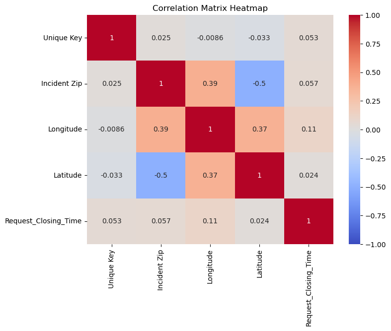

```python
import matplotlib.pyplot as plt
import seaborn as sns

# Select columns and drop rows with missing values
numerical_df = df[['Unique Key', 'Incident Zip', 'Longitude', 'Latitude', 'Request_Closing_Time']].dropna()

# Compute the correlation matrix
correlation_matrix = numerical_df.corr()

# Print the correlation matrix
print("Correlation Matrix:")
print(correlation_matrix)

# Create and display the heatmap
plt.figure(figsize=(8, 6))
sns.heatmap(correlation_matrix, annot=True, cmap='coolwarm', vmin=-1, vmax=1, center=0)
plt.title("Correlation Matrix Heatmap")
plt.show()
```

```python
df.info()
```

```
<class 'pandas.core.frame.DataFrame'>
Index: 291107 entries, 0 to 300697
Data columns (total 16 columns):
 #   Column                  Non-Null Count   Dtype
---  ------                  --------------   -----
 0   Unique Key              291107 non-null  int64
 1   Created Date            291107 non-null  datetime64[ns]
 2   Closed Date             291107 non-null  datetime64[ns]
 3   Agency                  291107 non-null  object
 4   Complaint Type          291107 non-null  object
 5   Descriptor              291107 non-null  object
 6   Location Type           291107 non-null  object
 7   Incident Zip            291107 non-null  float64
 8   City                    291107 non-null  object
 9   Status                  291107 non-null  object
 10  Resolution Description  291107 non-null  object
 11  Borough                 291107 non-null  object
 12  Latitude                291107 non-null  float64
 13  Longitude               291107 non-null  float64
 14  Request_Closing_Time    291107 non-null  timedelta64[ns]
 15  Request_Closing_Hours   291107 non-null  float64
dtypes: datetime64[ns](2), float64(4), int64(1), object(8), timedelta64[ns](1)
memory usage: 37.8+ MB
```

3. Data Exploration

Provide four major insights through visualization that you come up after data mining

```python
df_clean = df.dropna(subset=["Complaint Type", "City", "Request_Closing_Time"])
```

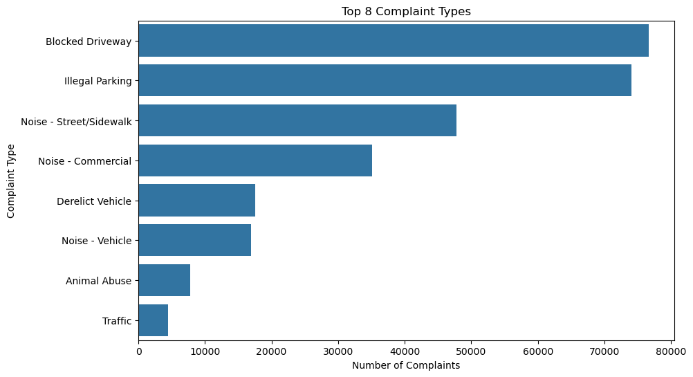

```python
import matplotlib.pyplot as plt
import seaborn as sns

plt.figure(figsize=(10, 6))
top_complaints = df_clean['Complaint Type'].value_counts().head(8)
sns.barplot(x=top_complaints.values, y=top_complaints.index)
plt.title("Top 8 Complaint Types")
plt.xlabel("Number of Complaints")
plt.ylabel("Complaint Type")
plt.show()
```

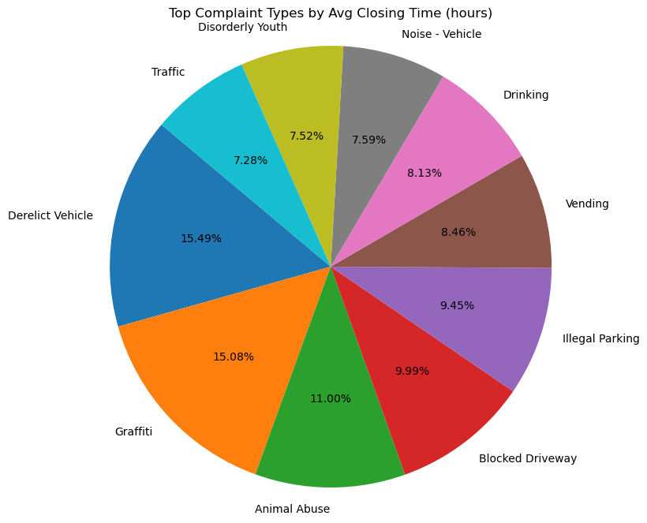

```python
import matplotlib.pyplot as plt

# Calculate average closing time per complaint type and get top 10
avg_closing = df_clean.groupby("Complaint Type")["Request_Closing_Time"].mean().sort_values(ascending=False).head(10)

# Plot as pie chart
plt.figure(figsize=(10, 8))
plt.pie(avg_closing.values, labels=avg_closing.index, autopct='%.2f%%', startangle=140)
plt.title("Top Complaint Types by Avg Closing Time (hours)")
plt.axis('equal')  # Ensures pie is drawn as a circle
plt.show()
```

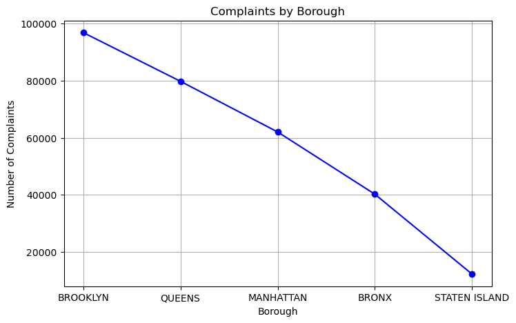

```python
# Count the number of complaints per borough
borough_counts = df_clean['Borough'].value_counts()

# Plot as a line graph
plt.figure(figsize=(8, 5))
plt.plot(borough_counts.index, borough_counts.values, marker='o', linestyle='-', color='blue')
plt.title("Complaints by Borough")
plt.xlabel("Borough")
plt.ylabel("Number of Complaints")
plt.grid(True)
plt.show()
```

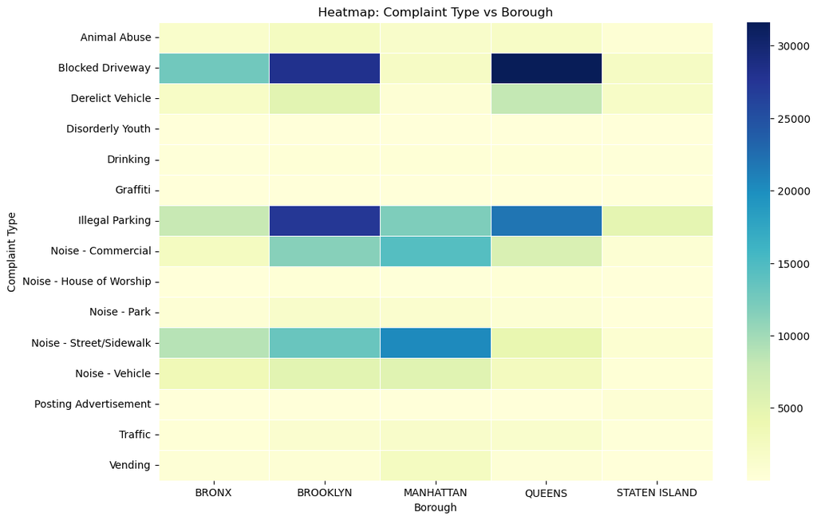

```python
plt.figure(figsize=(12, 8))
heatmap_data = pd.crosstab(df_clean['Complaint Type'], df_clean['Borough'])
sns.heatmap(heatmap_data, cmap="YlGnBu", linewidths=0.5)
plt.title("Heatmap: Complaint Type vs Borough")
plt.xlabel("Borough")
plt.ylabel("Complaint Type")
plt.show()
```

Arrange the complaint types according to their average 'Request_Closing_Time', categorized by various locations. Illustrate it through graph as well.

[figure not shown]

```python
# Convert dates to datetime
df_clean['Created Date'] = pd.to_datetime(df_clean['Created Date'], errors='coerce')
df_clean['Closed Date'] = pd.to_datetime(df_clean['Closed Date'], errors='coerce')

# Calculate closing time in hours
df_clean['Request_Closing_Hours'] = (df_clean['Closed Date'] - df_clean['Created Date']).dt.total_seconds() / 3600

# Drop rows with missing or invalid times
df_clean = df_clean[df_clean['Request_Closing_Hours'] > 0]

# Group by Complaint Type and City, and get average
grouped = df_clean.groupby(['Complaint Type', 'City'])['Request_Closing_Hours'].mean().reset_index()

# Sort by average closing time
grouped = grouped.sort_values(by='Request_Closing_Hours', ascending=False)

# Plot
plt.figure(figsize=(14, 8))
sns.barplot(data=grouped, x='Request_Closing_Hours', y='Complaint Type', hue='City')
plt.title("Avg Request Closing Time by Complaint Type and Location ")
plt.xlabel("Avg Closing Time (Hours)")
plt.ylabel("Complaint Type")
plt.tight_layout()
plt.show()
```

3. Statical Testing

Test 1: Whether the average response time across complaint types is similar or not.

● State the Null Hypothesis (H0) and Alternate Hypothesis (H1).

● Perform the statistical test and provide the p-value.

● Interpret the results to accept or reject the Null Hypothesis.

```python
from scipy.stats import f_oneway

# Create df_clean by removing rows with missing or negative Request_Closing_Time
df_clean = df.dropna(subset=['Request_Closing_Time', 'Complaint Type']).copy()

# Convert 'Request_Closing_Time' to numeric (in hours) and filter out rows with negative or zero values
df_clean['Request_Closing_Time'] = df_clean['Request_Closing_Time'].dt.total_seconds() / 3600  # Convert to hours
df_clean = df_clean[df_clean['Request_Closing_Time'] > 0]

# Filter out complaint types with too few samples for statistical validity (e.g., at least 30 entries)
complaint_counts = df_clean['Complaint Type'].value_counts()
valid_complaints = complaint_counts[complaint_counts > 30].index
filtered_df = df_clean[df_clean['Complaint Type'].isin(valid_complaints)]

# Prepare data for ANOVA test: list of arrays of request closing times grouped by complaint type
groups = [group["Request_Closing_Time"].values for name, group in filtered_df.groupby("Complaint Type")]

# Perform One-Way ANOVA
f_stat, p_value = f_oneway(*groups)

# Print results
print("F-statistic:", f_stat)
print("p-value:", p_value)

# Interpret the result based on p-value
if p_value < 0.05:
    print("→ Reject the null hypothesis")
else:
    print("→ Fail to reject the null hypothesis")
```

```
F-statistic: 578.9120337398356
p-value: 0.0
→ Reject the null hypothesis
```

Test 2: Whether the type of complaint or service requested and location are related.

● State the Null Hypothesis (H0) and Alternate Hypothesis (H1).

● Perform the statistical test and provide the p-value.

● Interpret the results to accept or reject the Null Hypothesis.

```python
from scipy.stats import chi2_contingency


# Remove rows with missing Complaint Type or Borough
df_clean = df.dropna(subset=['Complaint Type', 'Borough'])

# Create a contingency table of complaint types by borough
table = pd.crosstab(df_clean['Complaint Type'], df_clean['Borough'])

# Perform Chi-Square test
chi2, p, dof, expected = chi2_contingency(table)

# Print results
print(f"Chi-square: {chi2:.4f}")
print(f"P-value: {p:.6f}")

# Conclusion
if p < 0.05:
    print("Reject the null hypothesis: There is a significant relationship between complaint type and location")
else:
    print("Fail to reject the null hypothesis: No significant relationship between complaint type and location.")
```

```
Chi-square: 73264.6216
P-value: 0.000000
Reject the null hypothesis: There is a significant relationship between complaint type and location
```

```python
df.info()
```

```
<class 'pandas.core.frame.DataFrame'>
Index: 291107 entries, 0 to 300697
Data columns (total 16 columns):
 #   Column                  Non-Null Count   Dtype
---  ------                  --------------   -----
 0   Unique Key              291107 non-null  int64
 1   Created Date            291107 non-null  datetime64[ns]
 2   Closed Date             291107 non-null  datetime64[ns]
 3   Agency                  291107 non-null  object
 4   Complaint Type          291107 non-null  object
 5   Descriptor              291107 non-null  object
 6   Location Type           291107 non-null  object
 7   Incident Zip            291107 non-null  float64
 8   City                    291107 non-null  object
 9   Status                  291107 non-null  object
 10  Resolution Description  291107 non-null  object
 11  Borough                 291107 non-null  object
 12  Latitude                291107 non-null  float64
 13  Longitude               291107 non-null  float64
 14  Request_Closing_Time    291107 non-null  timedelta64[ns]
 15  Request_Closing_Hours   291107 non-null  float64
dtypes: datetime64[ns](2), float64(4), int64(1), object(8), timedelta64[ns](1)
memory usage: 37.8+ MB
```